# Reading the Titanic dataset

## File details

This program was written by Steve Simon on 2025-01-06 and is placed in the public domain. You can use this program any way you please.

This program reads data on mortality of passengers on the Titanic. Refer to the [data dictionary](https://github.com/pmean/data/blob/main/files/titanic.yaml) for a more detailed description.

```r
R.version.string
```

```
[1] "R version 4.4.3 (2025-02-28 ucrt)"
```

```r
Sys.Date()
```

```
[1] "2025-04-17"
```

```r
library(epitools)
library(glue)
library(tidyverse)
```

#### Documentation of the intermediate datasets

- ti: Data as originally read in from the text file
- ti_1: Convert survived to a factor
- ti_2: Created new variable, third_class
- ti_3: Created new variable, child
- pclass_counts: counts and percentages for each passenger class
- sex_survived_crosstab: counts for survived by sex

# — Begin Part 1 —

## Reading in the Titanic data set

```r
fn <- "../data/titanic.csv"
ti <- read_csv(fn,
  col_types="ccncn")
glimpse(ti)
```

```
Rows: 1,313
Columns: 5
$ name     <chr> "Allen, Miss Elisabeth Walton", "Allison, Miss Helen Loraine"…
$ pclass   <chr> "1st", "1st", "1st", "1st", "1st", "1st", "1st", "1st", "1st"…
$ age      <dbl> 29.00, 2.00, 30.00, 25.00, 0.92, 47.00, 63.00, 39.00, 58.00, …
$ sex      <chr> "female", "female", "male", "female", "male", "male", "female…
$ survived <dbl> 1, 0, 0, 0, 1, 1, 1, 0, 1, 0, 0, 1, 1, 1, 0, 1, 0, 0, 1, 1, 1…
```

## Peek at the bottom of the data

```r
ti |>
  slice_tail(n=10)
```

```
# A tibble: 10 × 5
   name                   pclass   age sex    survived
   <chr>                  <chr>  <dbl> <chr>     <dbl>
 1 Yasbeck, Mr Antoni     3rd       27 male          0
 2 Yasbeck, Mrs Antoni    3rd       15 female        1
 3 Youssef, Mr Gerios     3rd       NA male          0
 4 Zabour, Miss Hileni    3rd       NA female        0
 5 Zabour, Miss Tamini    3rd       NA female        0
 6 Zakarian, Mr Artun     3rd       27 male          0
 7 Zakarian, Mr Maprieder 3rd       26 male          0
 8 Zenni, Mr Philip       3rd       22 male          0
 9 Lievens, Mr Rene       3rd       24 male          0
10 Zimmerman, Leo         3rd       29 male          0
```

#### Comments on the code

The [slice_tail](https://dplyr.tidyverse.org/reference/slice.html) function (part of the dplyr/tidyverse libraries) displays one or more rows of data at the bottom of a data set. This is similar to the [tail](https://stat.ethz.ch/R-manual/R-devel/library/utils/html/head.html) function in base R.

For large files, it is often worthwhile to look at the bottom of dataset after you read it in. Often the first few rows of data look fine. but problems crop up in the middle of the file which distort the data from that point onward. Other times, you might find stray comments or extra blank lines at the end of a text file. You won’t notice these problems if you don’t look at the bottom of the file.

## Descriptive statistics on age

```r
ti |>
  summarize(
    age_mean=round(mean(age, na.rm=TRUE), 1),
    age_sd=round(sd(age, na.rm=TRUE), 1),
    age_min=min(age, na.rm=TRUE),
    age_max=max(age, na.rm=TRUE),
    age_missing=sum(is.na(age)))
```

```
# A tibble: 1 × 5
  age_mean age_sd age_min age_max age_missing
     <dbl>  <dbl>   <dbl>   <dbl>       <int>
1     30.4   14.3    0.17      71         557
```

## More information on the extremes

```r
ti |>
  slice_min(age, na_rm=TRUE)
```

```
# A tibble: 1 × 5
  name                                   pclass   age sex    survived
  <chr>                                  <chr>  <dbl> <chr>     <dbl>
1 Dean, Miss Elizabeth Gladys (Millvena) 3rd     0.17 female        1
```

```r
ti |>
  slice_max(age, na_rm=TRUE)
```

```
# A tibble: 3 × 5
  name                       pclass   age sex   survived
  <chr>                      <chr>  <dbl> <chr>    <dbl>
1 Artagaveytia, Mr Ramon     1st       71 male         0
2 Goldschmidt, Mr George B   1st       71 male         0
3 Mitchell, Mr Henry Michael 2nd       71 male         0
```

#### Comments on the code

The [slice_min](https://dplyr.tidyverse.org/reference/slice.html) function is part of the dplyr/tidyverse library. It will select the row or rows of a data frame or tibble that have the smallest value for a particular variable. The slice_max function does the same for the largest value. Note the use of the na_rm argument, which is inconsistent with the na.rm argument found in the min and max functions.

#### Interpretation of the output

The youngest passenger, a female in third class, survived. There were three passengers tied for the oldest. All were men in first or second class and all of them died.

# — Begin Part 2 —

## Creating factors

```r
ti |>
  mutate(
    survived=
      factor(
        survived,
        levels=c(0, 1),
        labels=c("dead", "alive"))) -> ti_1
```

## Counts and percentages

```r
ti_1 |>
  count(pclass) |>
  mutate(total=sum(n)) |>
  mutate(pct=100*n/total) |>
  mutate(pct=glue("{n}/{total} ({round(pct)}%)")) |>
  select(-n, -total)
```

```
# A tibble: 3 × 2
  pclass pct
  <chr>  <glue>
1 1st    322/1313 (25%)
2 2nd    280/1313 (21%)
3 3rd    711/1313 (54%)
```

#### Comments on the code

The [count](https://dplyr.tidyverse.org/reference/count.html) function (part of the dplyr/tidyverse libraries) counts the number of observations in each level of a categorical variable. You can also use the [table](https://stat.ethz.ch/R-manual/R-devel/library/base/html/table.html) function in base R, which produces results in a slightly different format.

The [sum](https://stat.ethz.ch/R-manual/R-devel/library/base/html/sum.html) function adds up all the values. When placed inside the mutate function, it creates a new column with the same sum beside each row. This allows us to compute a percentage later.

The [glue](https://glue.tidyverse.org/) function (part of the glue library) allows you to insert numbers into nicely formatted strings. You can also use the [paste and paste0](https://stat.ethz.ch/R-manual/R-devel/library/base/html/paste.html) functions to do the same thing. If you are familiar with how C and C++ produces nicely formatted output, you might consider using the [sprintf](https://stat.ethz.ch/R-manual/R-devel/library/base/html/sprintf.html) function.

#### Interpretation of the output

More than half of the passengers were in third class. Among the remaining passengers, there were slightly more first class than second class passengers.

# — Begin Part 3 —

## Crosstabulation

```r
ti_1 |>
    count(pclass, survived)
```

```
# A tibble: 6 × 3
  pclass survived     n
  <chr>  <fct>    <int>
1 1st    dead       129
2 1st    alive      193
3 2nd    dead       161
4 2nd    alive      119
5 3rd    dead       573
6 3rd    alive      138
```

```r
with(ti_1, table(pclass, survived))
```

```
      survived
pclass dead alive
   1st  129   193
   2nd  161   119
   3rd  573   138
```

```r
xtabs( ~ pclass + survived, data=ti_1)
```

```
      survived
pclass dead alive
   1st  129   193
   2nd  161   119
   3rd  573   138
```

#### Comments on the code

A crosstabulation shows counts across the combination of two different categorical variables. Although I prefer the count function, you can use the [table](https://stat.ethz.ch/R-manual/R-devel/library/base/html/table.html) function or the [xtabs](https://stat.ethz.ch/R-manual/R-devel/library/stats/html/xtabs.html) function.

The latter two functions produce the counts in a rectangular format. But both work poory with many of the tidyverse functions.

## Conditional probabilities

```r
ti_1 |>
  count(sex, survived) |>
    group_by(sex) |>
    mutate(total=sum(n)) |>
    mutate(pct=round(100*n/total)) |>
    mutate(
        pct=
            glue("{n}/{total} ({pct}%)")) |>
    select(-n, -total) |>
  pivot_wider(
    names_from=survived,
    values_from=pct)
```

```
# A tibble: 2 × 3
# Groups:   sex [2]
  sex    dead          alive
  <chr>  <glue>        <glue>
1 female 154/462 (33%) 308/462 (67%)
2 male   709/851 (83%) 142/851 (17%)
```

The key question in the Titanic dataset is survival. Who lived and who died. Kate Winslet lived, but sad to say, Leonardo diCaprio did not. So what was the survival rate for all women? For all men?

For this, you can see that two-thirds of the women survived, but only one out of six men did.

# — Begin Part 4 —

## Bar chart with percents

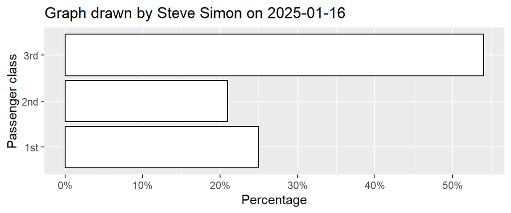

```r
ticks <- seq(from = 0, to = 50, by = 10)

ti |>
  count(pclass) |>
  mutate(total = sum(n)) |>
  mutate(pct = round(100*n/total)) |>
  ggplot() +
  aes(x=pclass, y=pct) +
  geom_col(color="black", fill="white") +
  ggtitle("Graph drawn by Steve Simon on 2025-01-16") +
  xlab("Passenger class") +
  ylab("Percentage") +
  scale_y_continuous(
    breaks=ticks,
    labels=glue("{ticks}%")) +
  coord_flip()
```

#### Comments on the code

The [geom_col](https://ggplot2.tidyverse.org/reference/geom_bar.html) function (parts of the ggplot2/tidyverse libraries) draws a bar chart with a bar for each level of the “x” variable and where the height of each bar is defined by the “y” variable. Don’t confuse this with the geom_bar function which displays the counts for each level of a categorical variable.

There is also a [barchart](https://stat.ethz.ch/R-manual/R-devel/library/graphics/html/barplot.html) function in the graphics library (part of base R) that you can use.

## Barplot of counts, code

```r
simple_barplot <-
  ggplot(ti, aes(x=PClass)) +
    geom_bar()
```

## Barplot of percentages, code

```r
percentages_barplot <-
  ggplot(ti, aes(x=PClass)) +
    geom_bar(aes(weight=100/n))
```

Use weights to get a bar chart of percentages.

## Barplot of percentages, code

```r
labeled_barplot <-
  percentages_barplot +
    scale_y_continuous(
      "Percent",
      breaks=c(0, 20, 40),
      labels=c("0%", "20%", "40%"))
```

You can control how the y-axis is labeled with the scale_y_continuous function.

## New categorical variables

```r
ti$child <- case_when(
  is.na(ti$Age) ~ "Unknown",
  ti$Age <=  0   ~ "Invalid",
  ti$Age <  18    ~ "Yes",
  ti$Age >= 18    ~ "No")
```

[output not shown]

```r
table(ti$child, useNA="always")
```

```
<NA>
   0
```

There are several ways to create a new categorical variable in R, but the easiest way is through the use of logical comparisons.

## Quality check for child

```r
range(ti$Age[ti$child=="No"])
```

```
[1]  Inf -Inf
```

```r
range(ti$Age[ti$child=="Yes"])
```

```
[1]  Inf -Inf
```

```r
table(ti$Age[ti$child=="Unknown"], useNA="always")
```

```
<NA>
   0
```

Anytime you create a new categorical variable, you should run a quality check to make sure nothing is wrong. The range function is useful for this.

## More on recoding

```r
ti$lower_class <- case_when(
  is.na(ti$PClass) ~ "Unknown",
  ti$PClass=="1st" ~ "No",
  ti$PClass=="2nd" ~ "Yes",
  ti$PClass=="3rd" ~ "Yes")
```

[output not shown]

## More on recoding, output

```r
table(
  ti$lower_class,
  ti$PClass,
  useNA="always")
```

```
       <NA>
  <NA>    0
```

As before, it’s a good a idea to run a crosstabulation to verify that the new coding was done properly.

## Creating multi-level categories, code

```r
ti$age_groups <- case_when(
  is.na(ti$Age) ~ "Missing",
  ti$Age <= 0   ~ "Invalid",
  ti$Age <= 1.5 ~ "Infant",
  ti$Age <= 12  ~ "Child",
  ti$Age <= 19  ~ "Teenager",
  ti$Age >  19  ~ "Adult")
```

[output not shown]

Here’s a more complex example. Notice that I check instinctively for invalid values.

## Creating multi-level categories, output

```r
table(ti$age_groups, useNA="always")
```

```
<NA>
   0
```

## Quality check

```r
range(ti$Age[ti$age_groups=="Infant"])
```

```
[1]  Inf -Inf
```

```r
range(ti$Age[ti$age_groups=="Child"])
```

```
[1]  Inf -Inf
```

```r
range(ti$Age[ti$age_groups=="Teenager"])
```

```
[1]  Inf -Inf
```

```r
range(ti$Age[ti$age_groups=="Adult"])
```

```
[1]  Inf -Inf
```

#### Comments on the code

The [factor](https://stat.ethz.ch/R-manual/R-devel/library/base/html/factor.html) function (part of base R), attaches descriptive labels to categorical data that otherwise might use cryptic number or letter codes.

In this code, I store any changes made to the original data as a new tibble. If you do this, document at the top of the program what change was made in the new file.

## Creating factors, 2

```r
ti_1 |>
  count(survived) |>
  mutate(total=sum(n)) |>
  mutate(pct=round(100*n/total)) |>
  mutate(pct=glue("{n}/{total} ({pct}%)")) |>
  select(-n, -total)
```

```
# A tibble: 2 × 2
  survived pct
  <fct>    <glue>
1 dead     863/1313 (66%)
2 alive    450/1313 (34%)
```

#### Interpretation of the output

Things did not go well for the passengers of the Titanic. Only about a third of the passengers survived.

## Re-ordering categories

```r
ti_1 |>
  mutate(pclass=factor(pclass, levels=c("3rd", "2nd", "1st"))) |>
  count(pclass) |>
  mutate(total=sum(n)) |>
  mutate(pct=round(100*n/total)) |>
  mutate(pct=glue("{n}/{total} ({pct}%)")) |>
  select(-n, -total)
```

```
# A tibble: 3 × 2
  pclass pct
  <fct>  <glue>
1 3rd    711/1313 (54%)
2 2nd    280/1313 (21%)
3 1st    322/1313 (25%)
```

#### Comments on the code

When R processes strings, it will arrange them by default in alphabetical order. If you want a different order, use that preferred order in the levels argument of the factor function.

## Recoding categorical data, 1

```r
ti_1 |>
  mutate(
    third_class=
      case_when(
        is.na(pclass) ~ "unknown",
        pclass=="1st" ~ "no",
        pclass=="2nd" ~ "no",
        pclass=="3rd" ~ "yes")) -> ti_2
```

#### Comments on the code

The [case_when](https://dplyr.tidyverse.org/reference/case_when.html) function (part of the dply/tidyverse libraries) will allow you to create a new variable based on various logical comparisons. You list a sequence of conditions on the left side of the tilde and the value that you want to assign if that condition is true on the right side of the tilde. The conditions are evaluated in sequence and the value chosen is the first logical comparison that evaluates to TRUE.

There are no missing values for pclass, but accounting for missing values as the first comparison is a good habit to get into.

## Recoding categorical data, 2

```r
ti_2 |>
  count(third_class) |>
  mutate(total=sum(n)) |>
  mutate(pct=round(100*n/total)) |>
  mutate(pct=glue("{n}/{total} ({pct}%)")) |>
  select(-n, -total)
```

```
# A tibble: 2 × 2
  third_class pct
  <chr>       <glue>
1 no          602/1313 (46%)
2 yes         711/1313 (54%)
```

#### Comments on the code

The [case_when](https://dplyr.tidyverse.org/reference/case_when.html) function (part of the dplyr/tidyverse libraries) creates a new variable or modifies an old variable based on a sequence of logical conditions.

#### Interpretation of the output

As noted earlier, a bit more than half of the passengers were in third class.

## Converting continuous data to categorical data, 1

```r
ti_2 |>
  mutate(
    child=
      case_when(
        is.na(age) ~ "Unknown",
        age <= 0 ~ "Invalid",
        age < 18 ~ "Yes",
        TRUE ~ "No")) -> ti_3
```

#### Comments on the code

Notice again how you should check for missing values first. The code also checks for zero or negative ages (although there aren’t any) just because it is a good habit you should develop.

## Converting continuous data to categorical data, 2

```r
ti_3 |>
  count(child) |>
  mutate(total=sum(n)) |>
  mutate(pct=round(100*n/total)) |>
  mutate(pct=glue("{n}/{total} ({pct}%)")) |>
  select(-n, -total)
```

```
# A tibble: 3 × 2
  child   pct
  <chr>   <glue>
1 No      660/1313 (50%)
2 Unknown 557/1313 (42%)
3 Yes     96/1313 (7%)
```

## Two way crosstabulation

```r
ti_3 |>
    count(sex, survived) -> sex_survived_crosstab
sex_survived_crosstab
```

```
# A tibble: 4 × 3
  sex    survived     n
  <chr>  <fct>    <int>
1 female dead       154
2 female alive      308
3 male   dead       709
4 male   alive      142
```

#### Comments on the code

The count function can also work with two (or more arguments). In this example, it calculates every possible combination of sex and survived:

- female died
- female alive
- male died
- male alive

#### Interpretation of the output.

The largest group on the Titanic was male deaths. There were only about half as many female survivors. The smallest counts were male survivors and female deaths.

## Arranged in a table

```r
sex_survived_crosstab |>
    pivot_wider(
        names_from="survived",
        values_from="n") -> sex_survived_crosstabtable
sex_survived_crosstabtable
```

```
# A tibble: 2 × 3
  sex     dead alive
  <chr>  <int> <int>
1 female   154   308
2 male     709   142
```

#### Comments on the code

The [pivot_wider](https://tidyr.tidyverse.org/reference/pivot_wider.html) function (part of the dplyr/tidyverse libraries) will spread data across multiple columns. In this case, it places the counts of the survivors in one column and places the counts of the deaths in a separate column. This produces a rectangular format that most other statistical software programs use. In fact, the table function with two arguments will also produce the table you see here. There’s a subtle difference, though. The table function produces an array rather than a tibble.

If you wanted the counts for males in one column and the counts for females in a separate column, change the names from argument from “survived” to “sex”.

## Overall percents

```r
sex_survived_crosstab |>
  mutate(total=sum(n)) |>
  mutate(pct=round(100*n/total))
```

```
# A tibble: 4 × 5
  sex    survived     n total   pct
  <chr>  <fct>    <int> <int> <dbl>
1 female dead       154  1313    12
2 female alive      308  1313    23
3 male   dead       709  1313    54
4 male   alive      142  1313    11
```

#### Comments on the code

There are three different percentages that you can calculate for this table. The first mutate command places the grand total (1,313) in each row of the data and the second mutate command computes a percentage. For the sake of simplicity, I did not use the glue function to create a nice display for these percentage.

## Percents by sex

```r
sex_survived_crosstab |>
  group_by(sex) |>
  mutate(total=sum(n)) |>
  mutate(pct=round(100*n/total)) |>
  filter(survived=="alive") |>
  mutate(pct_survived=glue("{pct}% ({n}/{total})")) |>
  ungroup() |>
  select(survived, pct_survived)
```

```
# A tibble: 2 × 2
  survived pct_survived
  <fct>    <glue>
1 alive    67% (308/462)
2 alive    17% (142/851)
```

#### Comments on the code

The [group_by](https://dplyr.tidyverse.org/reference/group_by.html) function (part of the dplyr/tidyverse libraries) creates a grouped tibble. A grouped tibble is a modification of the tibble that allows you to make calculations across subsets. In this case, the mutate function immediately following the group_by statement calculates separate totals for male and female passengers. This produces a set of conditional probabilities, the probability of death/survival separately for males and females.

Since death/survival is a binary event, you do not need to display both. The filter command keeps the survival probabilities and drops the death probabilities.

#### Interpretation of the output

Most of the female passengers survived, about two out of every three. Very few male passengers survived, about one out of every six.

## Percents by survived

```r
sex_survived_crosstab |>
  group_by(survived) |>
  mutate(total=sum(n)) |>
  mutate(pct=round(100*n/total)) |>
  filter(sex=="female")  |>
  mutate(pct_female=glue("{pct}% ({n}/{total})")) |>
  ungroup() |>
  select(survived, pct_female)
```

```
# A tibble: 2 × 2
  survived pct_female
  <fct>    <glue>
1 dead     18% (154/863)
2 alive    68% (308/450)
```

#### Comments on the code

Using survived as the argument in the group_by function creates a different set of conditional probabilities, The probability of being a male or female passenger given that you survived or given that you died.

#### Interpretation of the output

Only a small percentage of deaths (less than one in five) was female deaths. Among survivors, more than two-thrids were female.

## clustered bar chart, 1

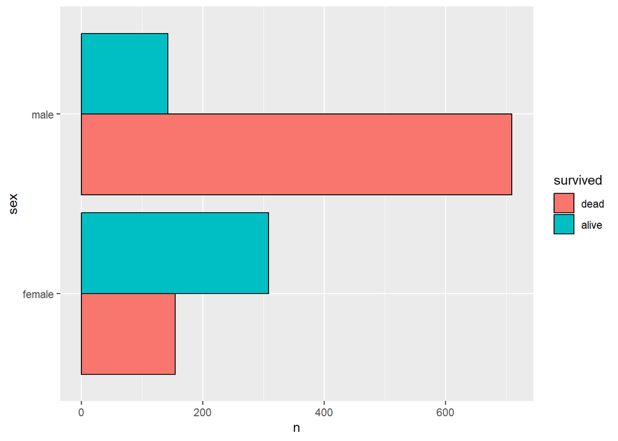

```r
sex_survived_crosstab |>
    ggplot() +
      aes(x=sex, y=n, fill=survived) +
    coord_flip() +
      geom_col(
        color="black",
        position="dodge")
```

#### Comments on the code

The geom_col function can produce clustered bar charts. The cluster is defined by the fill argument in the aes function. The position=“dodge” argument inside the geom_col function tells R that you want the clustered bars to appears side by side.

#### Interpretation of the output

The largest bar with a count of over 700 is for male deaths. The next largest bar, slighltly more than 300 is for female survivors. The two smallest bars around 150 passengers each are for male survivors and female deaths.

## clustered bar chart, 2

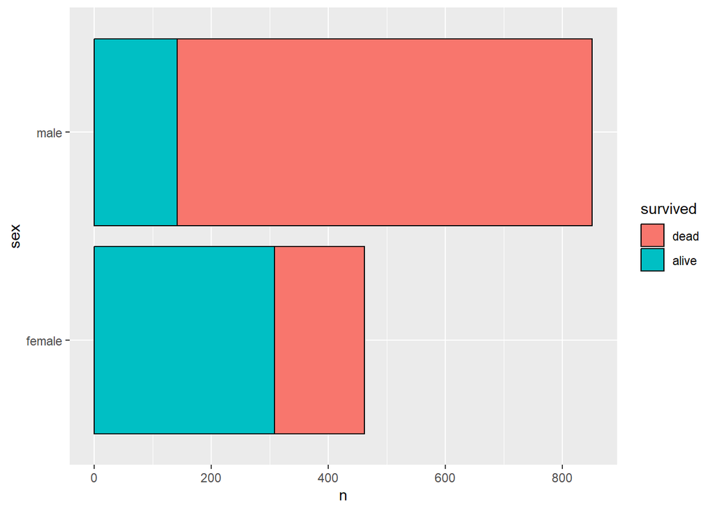

```r
sex_survived_crosstab |>
    ggplot() +
      aes(x=sex, y=n, fill=survived) +
    coord_flip() +
      geom_col(
        color="black",
        position="stack")
```

#### Comments on the code

If you replace position=“dodge” with position= “stack”, the bars are placed on the left and right of each other (or top and bottom if you didn’t use coord_flip). This makes for a slightly different interpretation.

#### Interpretation of the output

The vast majority of male passengers died, while most of the female passengers survived.

## Odds ratio

```r
oddsratio(x=ti_3$sex, y=ti_3$survived)
```

```
$data
         Outcome
Predictor dead alive Total
   female  154   308   462
   male    709   142   851
   Total   863   450  1313

$measure
         odds ratio with 95% C.I.
Predictor  estimate      lower     upper
   female 1.0000000         NA        NA
   male   0.1004472 0.07686819 0.1305053

$p.value
         two-sided
Predictor midp.exact fisher.exact   chi.square
   female         NA           NA           NA
   male            0 4.826448e-74 3.425855e-74

$correction
[1] FALSE

attr(,"method")
[1] "median-unbiased estimate & mid-p exact CI"
```

#### Comments on the code

The [oddsratio](https://cran.r-project.org/web/packages/epitools/epitools.pdf) function (part of the epitools package) uses a bit different syntax. It does not have a data= argument and that means that you need to specify both the tibble and the variable separated by a dollar sign. This also makes it difficult for you to include this function inside a series of pipes.

This is common for many libraries (and for major parts of base R) and is a glaring inconsistency in the R language.

#### Interpretation of the output

The odds of survival is ten times lower for males than females. The confidence interval excludes the value of 1, so there is a statistically significant decrease in risk of survival for male passengers compared to female passengers.

## Relative risk

```r
riskratio(x=ti_3$sex, y=ti_3$survived)
```

```
$data
         Outcome
Predictor dead alive Total
   female  154   308   462
   male    709   142   851
   Total   863   450  1313

$measure
         risk ratio with 95% C.I.
Predictor  estimate     lower     upper
   female 1.0000000        NA        NA
   male   0.2502938 0.2125647 0.2947195

$p.value
         two-sided
Predictor midp.exact fisher.exact   chi.square
   female         NA           NA           NA
   male            0 4.826448e-74 3.425855e-74

$correction
[1] FALSE

attr(,"method")
[1] "Unconditional MLE & normal approximation (Wald) CI"
```

#### Comments on the code

The riskratio function is also part of the epitools library and is documented in the previous link.

#### Interpretation of the output

The probability of survival is four times lower for males than females. Notice that this is quite different from the odds ratio. When to use the odds ratio and when to use the relative risk is well beyond the scope of this class. I have an [informal explanation](http://www.new.pmean.com/or-vs-rr/) of the issues involved on my website that happens to use this same dataset as one of the illustrative examples.

The confidence interval excludes the value of 1, so there is a statistically significant decrease in risk of survival for male passengers compared to female passengers.

## Save everything

```r
save.image("../data/demo-04.RData")
```